# Data Science Intro

## Loading data

This basic of data analysis. We will use mtcars small datasets in this session just to get some idea of how data anallysis or early stage of data science look like.We will read data from r , lookk the structure of data and visualize the data.

#### Description of data

Motor Trend Car Road Tests

Description

The data was extracted from the 1974 Motor Trend US magazine, and comprises fuel consumption and 10 aspects of automobile design and performance for 32 automobiles (1973–74 models).

Usage

mtcars Format

A data frame with 32 observations on 11 variables.

- mpg Miles/(US) gallon
- cyl Number of cylinders
- disp Displacement (cu.in.)
- hp Gross horsepower
- drat Rear axle ratio
- wt Weight (1000 lbs)
- qsec 1/4 mile time
- vs V/S
- am Transmission (0 = automatic, 1 = manual) [,10] gear Number of forward gears [,11] carb Number of carburetors Source

Henderson and Velleman (1981), Building multiple regression models interactively. Biometrics, 37, 391–411.

```r
## loading Built in data
data(mtcars)
```

If you want to load external data:

```
new_data <- read.csv("file_name.csv")
```

```r
## shows first 6 value of the dataframe
head(mtcars)
```

```
##                    mpg cyl disp  hp drat    wt  qsec vs am gear carb
## Mazda RX4         21.0   6  160 110 3.90 2.620 16.46  0  1    4    4
## Mazda RX4 Wag     21.0   6  160 110 3.90 2.875 17.02  0  1    4    4
## Datsun 710        22.8   4  108  93 3.85 2.320 18.61  1  1    4    1
## Hornet 4 Drive    21.4   6  258 110 3.08 3.215 19.44  1  0    3    1
## Hornet Sportabout 18.7   8  360 175 3.15 3.440 17.02  0  0    3    2
## Valiant           18.1   6  225 105 2.76 3.460 20.22  1  0    3    1
```

```r
## Getting help from the R
?mtcars
```

```r
## structure of the data
str(mtcars)
```

```
## 'data.frame':    32 obs. of  11 variables:
##  $ mpg : num  21 21 22.8 21.4 18.7 18.1 14.3 24.4 22.8 19.2 ...
##  $ cyl : num  6 6 4 6 8 6 8 4 4 6 ...
##  $ disp: num  160 160 108 258 360 ...
##  $ hp  : num  110 110 93 110 175 105 245 62 95 123 ...
##  $ drat: num  3.9 3.9 3.85 3.08 3.15 2.76 3.21 3.69 3.92 3.92 ...
##  $ wt  : num  2.62 2.88 2.32 3.21 3.44 ...
##  $ qsec: num  16.5 17 18.6 19.4 17 ...
##  $ vs  : num  0 0 1 1 0 1 0 1 1 1 ...
##  $ am  : num  1 1 1 0 0 0 0 0 0 0 ...
##  $ gear: num  4 4 4 3 3 3 3 4 4 4 ...
##  $ carb: num  4 4 1 1 2 1 4 2 2 4 ...
```

```r
## basic statistics of data
summary(mtcars)
```

```
##       mpg             cyl             disp             hp
##  Min.   :10.40   Min.   :4.000   Min.   : 71.1   Min.   : 52.0
##  1st Qu.:15.43   1st Qu.:4.000   1st Qu.:120.8   1st Qu.: 96.5
##  Median :19.20   Median :6.000   Median :196.3   Median :123.0
##  Mean   :20.09   Mean   :6.188   Mean   :230.7   Mean   :146.7
##  3rd Qu.:22.80   3rd Qu.:8.000   3rd Qu.:326.0   3rd Qu.:180.0
##  Max.   :33.90   Max.   :8.000   Max.   :472.0   Max.   :335.0
##       drat             wt             qsec             vs
##  Min.   :2.760   Min.   :1.513   Min.   :14.50   Min.   :0.0000
##  1st Qu.:3.080   1st Qu.:2.581   1st Qu.:16.89   1st Qu.:0.0000
##  Median :3.695   Median :3.325   Median :17.71   Median :0.0000
##  Mean   :3.597   Mean   :3.217   Mean   :17.85   Mean   :0.4375
##  3rd Qu.:3.920   3rd Qu.:3.610   3rd Qu.:18.90   3rd Qu.:1.0000
##  Max.   :4.930   Max.   :5.424   Max.   :22.90   Max.   :1.0000
##        am              gear            carb
##  Min.   :0.0000   Min.   :3.000   Min.   :1.000
##  1st Qu.:0.0000   1st Qu.:3.000   1st Qu.:2.000
##  Median :0.0000   Median :4.000   Median :2.000
##  Mean   :0.4062   Mean   :3.688   Mean   :2.812
##  3rd Qu.:1.0000   3rd Qu.:4.000   3rd Qu.:4.000
##  Max.   :1.0000   Max.   :5.000   Max.   :8.000
```

## Analysis

```r
## Length of the dataframe or rows
length(mtcars$mpg)
```

```
## [1] 32
```

```r
## No of rows and columns
NROW(mtcars)
```

```
## [1] 32
```

```r
NCOL(mtcars)
```

```
## [1] 11
```

```r
## Dimension of the dataframe
dim(mtcars)
```

```
## [1] 32 11
```

```r
## Columns name
names(mtcars)
```

```
##  [1] "mpg"  "cyl"  "disp" "hp"   "drat" "wt"   "qsec" "vs"   "am"   "gear"
## [11] "carb"
```

```r
## select a column by name
head(mtcars$mpg)
```

```
## [1] 21.0 21.0 22.8 21.4 18.7 18.1
```

```r
## select a column or rows
## dataframe[rows, columns]
mtcars[2,3:4]
```

```
##               disp  hp
## Mazda RX4 Wag  160 110
```

```r
## Finding missing value .
## na means not available
## table function gives count of data  and is.na uses condition to check if data is na or not
table(is.na(mtcars))
```

```
##
## FALSE
##   352
```

#### Correlation

Correlation is the relation between two variable or values. It lies between -1 and +1.The two values with: * correlation value near to -1 : strong negative relation * correlation value near to +1 : strong postive relation * correlation value near to 0 : weak relation

```r
cor(mtcars)
```

```
##             mpg        cyl       disp         hp        drat         wt
## mpg   1.0000000 -0.8521620 -0.8475514 -0.7761684  0.68117191 -0.8676594
## cyl  -0.8521620  1.0000000  0.9020329  0.8324475 -0.69993811  0.7824958
## disp -0.8475514  0.9020329  1.0000000  0.7909486 -0.71021393  0.8879799
## hp   -0.7761684  0.8324475  0.7909486  1.0000000 -0.44875912  0.6587479
## drat  0.6811719 -0.6999381 -0.7102139 -0.4487591  1.00000000 -0.7124406
## wt   -0.8676594  0.7824958  0.8879799  0.6587479 -0.71244065  1.0000000
## qsec  0.4186840 -0.5912421 -0.4336979 -0.7082234  0.09120476 -0.1747159
## vs    0.6640389 -0.8108118 -0.7104159 -0.7230967  0.44027846 -0.5549157
## am    0.5998324 -0.5226070 -0.5912270 -0.2432043  0.71271113 -0.6924953
## gear  0.4802848 -0.4926866 -0.5555692 -0.1257043  0.69961013 -0.5832870
## carb -0.5509251  0.5269883  0.3949769  0.7498125 -0.09078980  0.4276059
##             qsec         vs          am       gear        carb
## mpg   0.41868403  0.6640389  0.59983243  0.4802848 -0.55092507
## cyl  -0.59124207 -0.8108118 -0.52260705 -0.4926866  0.52698829
## disp -0.43369788 -0.7104159 -0.59122704 -0.5555692  0.39497686
## hp   -0.70822339 -0.7230967 -0.24320426 -0.1257043  0.74981247
## drat  0.09120476  0.4402785  0.71271113  0.6996101 -0.09078980
## wt   -0.17471588 -0.5549157 -0.69249526 -0.5832870  0.42760594
## qsec  1.00000000  0.7445354 -0.22986086 -0.2126822 -0.65624923
## vs    0.74453544  1.0000000  0.16834512  0.2060233 -0.56960714
## am   -0.22986086  0.1683451  1.00000000  0.7940588  0.05753435
## gear -0.21268223  0.2060233  0.79405876  1.0000000  0.27407284
## carb -0.65624923 -0.5696071  0.05753435  0.2740728  1.00000000
```

## Visualization

We will plot some of the plots to show some relation between attributes of data.

#### Density plot

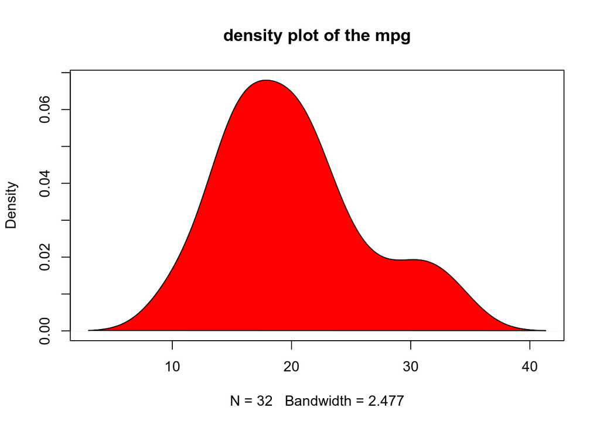

```r
## shows the type of distribution of the data, go through the statistics concept
## the y axis shows the density which is from 0 to 1
p <-density(mtcars$mpg)
plot(p, main= "density plot of the mpg")
polygon(p, col='red')
```

#### Scatterplot

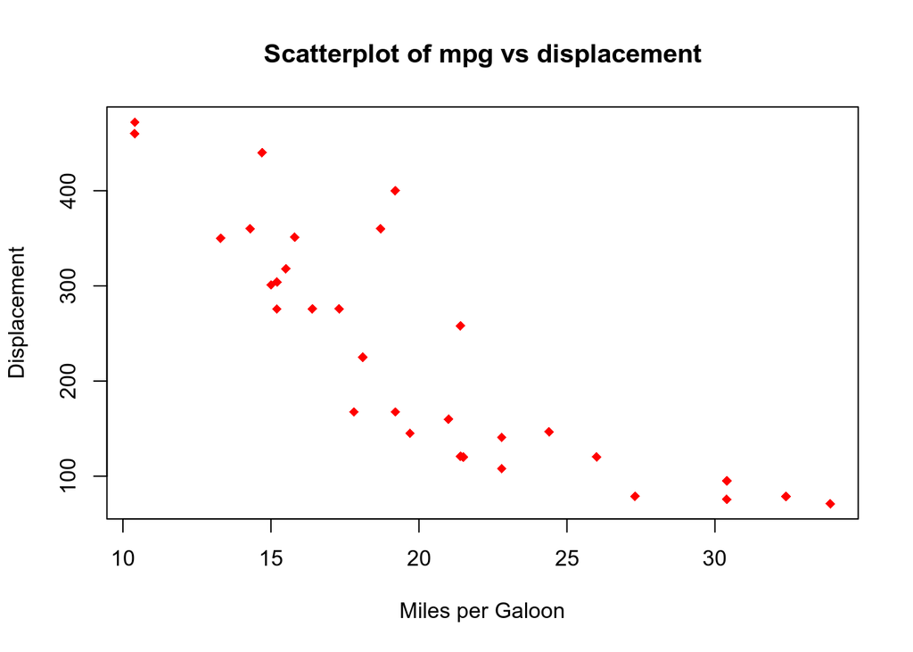

```r
## Used to know the relation between two columns data
p <- plot(mtcars$mpg,mtcars$disp, main= "Scatterplot of mpg vs displacement",xlab ="Miles per Galoon",ylab="Displacement",col="red",pch=18)
```

#### Boxplot

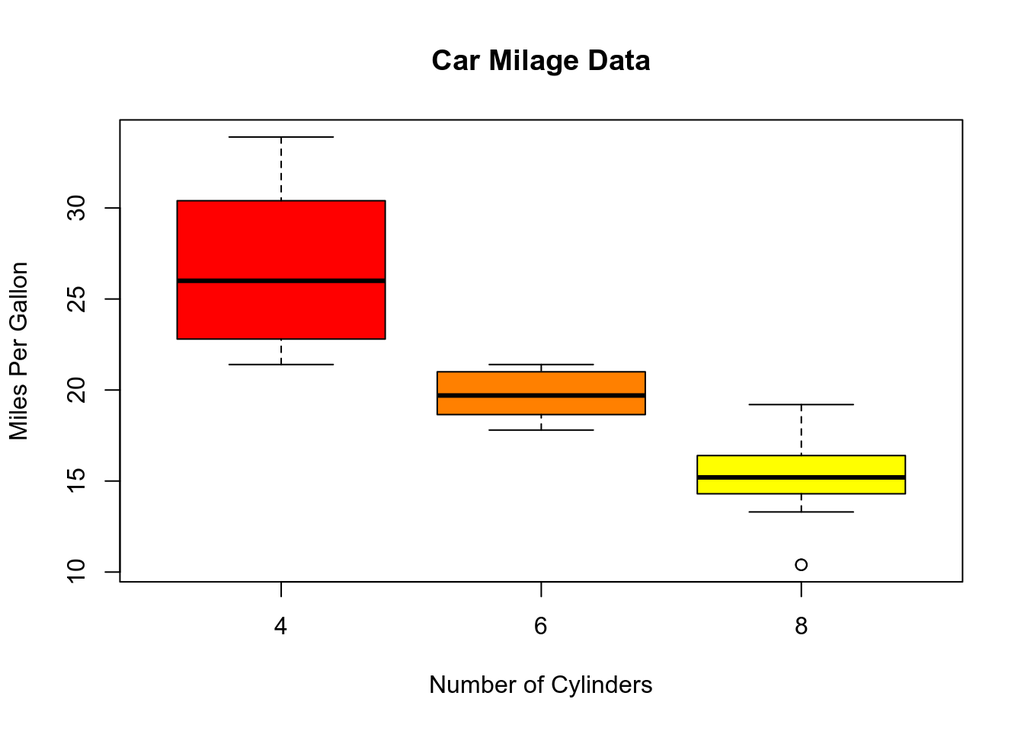

```r
## used to show the quartiles

boxplot(mpg~cyl,data=mtcars,col = heat.colors(3) ,main="Car Milage Data",
   xlab="Number of Cylinders", ylab="Miles Per Gallon")
```

#### Barplot

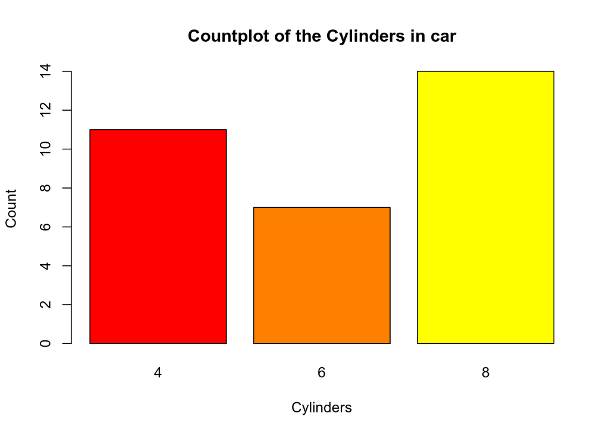

```r
# barplot is used to show the counts and also called count plot
barplot(table(mtcars$cyl),xlab = "Cylinders",ylab = "Count",col = heat.colors(3),main="Countplot of the Cylinders in car")
```

#### Histogram

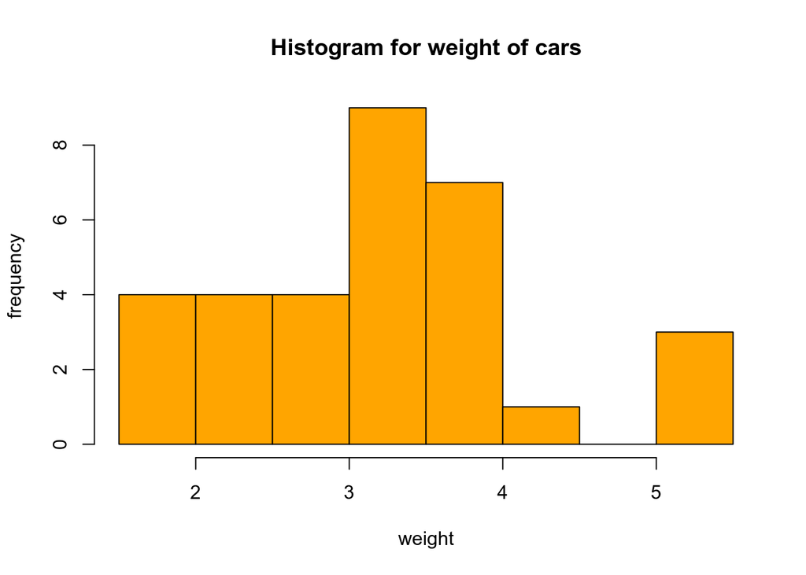

```r
## shows the frequency of the data between certain range
hist(mtcars$wt,col="orange", main = "Histogram for weight of cars",xlab = "weight",ylab = "frequency")
```

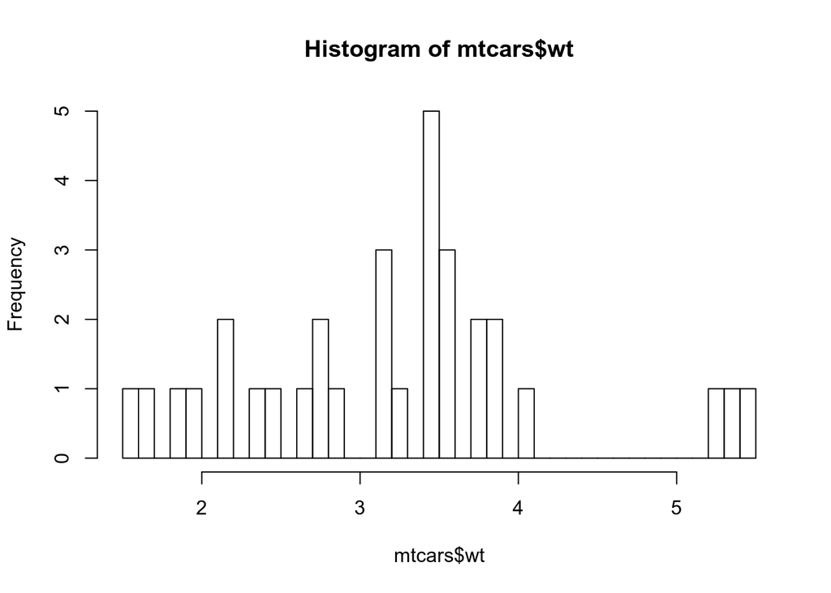

```r
## Histogram  + Density plot
hist(mtcars$wt,breaks = 32)
```

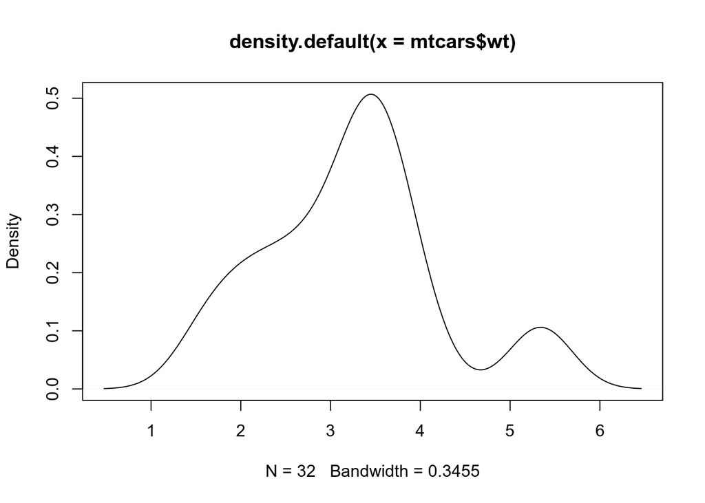

```r
plot(density(mtcars$wt))
```

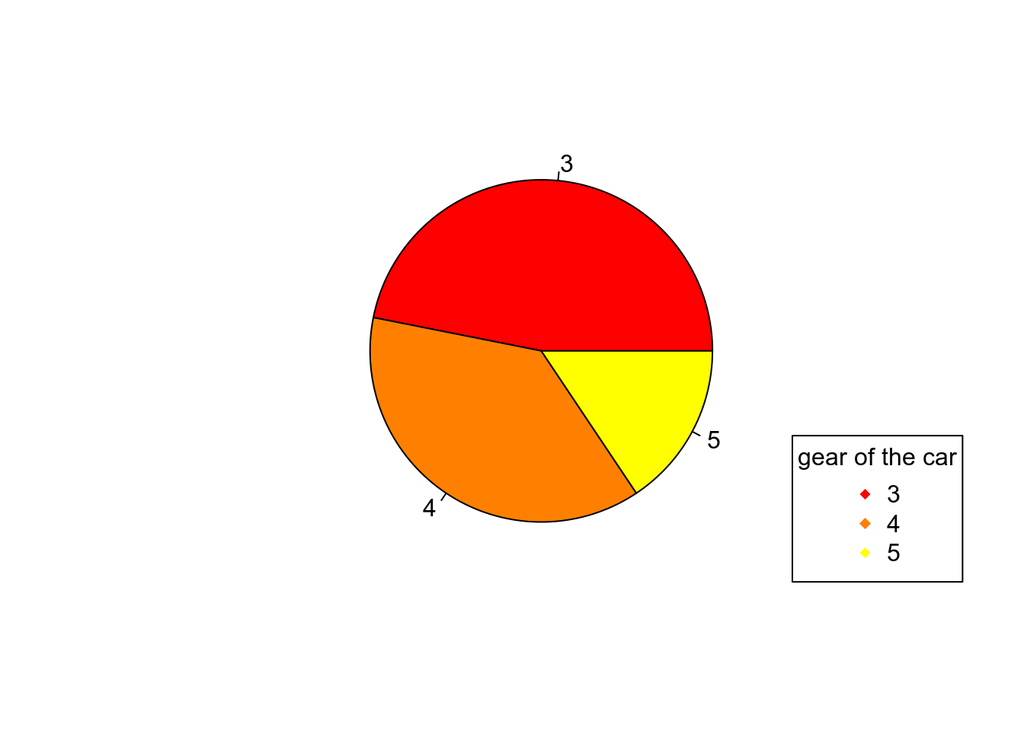

```r
## pie chart
pie(table(mtcars$gear),col = heat.colors(3))
legend(x = 'bottomright',
       legend = c("3","4","5"),
       col = heat.colors(3),pch=18,title = "gear of the car")
```

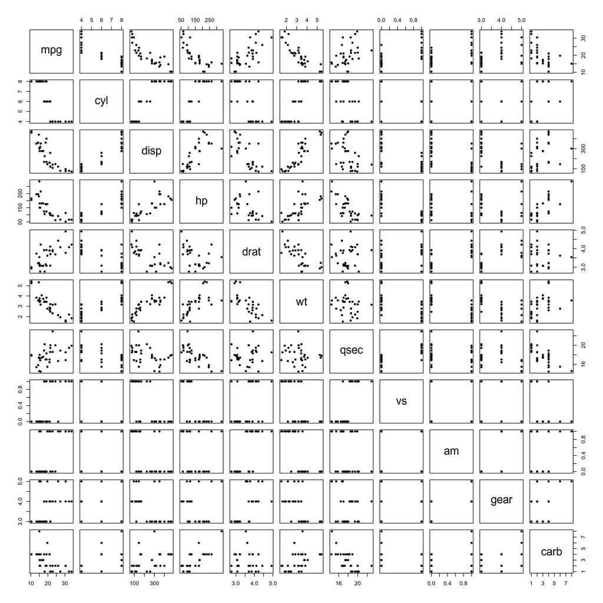

```r
## its is a correlation plot which shows relation between two columns
## pair() also create same plot
plot(mtcars,pch= 20)
```

## Conclusion

It is just basics of R , R has lots of packages for data collecting reading, cleaning , analysing visualizing andmodeling of the data. If you are intrested we can share our knowledge to you.

There are lots of data sets in R practice with them.